# Methodology

Ülo Maiväli

# Introduction

## Scientific method: the short version

Science has a single goal: to produce useful knowledge. “Useful” does not necessarily mean “monetized”, as there is more to human experience than business. It means any kind of knowledge that is interesting for any reason. Scientific product is used in technology, in medicine, in business, in mass murder, in politics, in music, and, frankly, in all human affairs. Without science the culture, and even thinking, would be different.

Scientists create and test theories on data. This means that science is a belief system, where existing beliefs are continually updated on new evidence. So science is evidence-based, but its more than that. It’s like a spider’s web that is continuously re-spun in response to a changing environment. Every piece of new data causes ripples across this world wide web of beliefs, and thus the web is never static, never finished. The main goal of methodology, the science of method, is to ensure optimal updating of beliefs.

## Rationality: the short version

We live in an uncertain world. While the world itself may or may not behave with true randomness, our attempts to collect data on it are hampered by measuring noise, random variation, and bias. Thus any attempt on making sense of the world must come to grips with these sources of uncertainty.

What makes a rational entity? Perhaps it is its goal of making the most of limited, noisy and biased information to formulate degrees of belief; and as a step further, to convert these beliefs into optimal decisions. We can make sense of the concept of rational beliefs by thinking of a spectrum of uncertainties, beginning with radical uncertainty, where we have no relevant information to limit the possibilities and on the other end of the continuum, completely understood uncertainty exemplified by games of chance. If we think of uncertainty in terms of the risk of something happening, then we immediately get that the radical uncertainty side of the continuum is deeply unpleasant, because the risks it describes are essentially unknowable – they can be very large, very small, or anything in between. In contrast, the games of chance are much more satisfying, as they are perfectly understood in the sense that we can from simple models calculate the exact long-run relative frequencies of any conceivable outcome (and these frequencies can be very close to truth in a real casino).

Somewhere inside of this continuum lies every scientific question that we might want to answer on empirical data. What scientists often do is to try to identify interesting questions that are as far away as possible from the radical uncertainty side of things, and then to apply simple stochastic models that are close to those employed for the games of chance, and hope that the modeling is somehow relevant in the real world. Every statistical model that uses binomial distribution to predict binary outcomes (dead/alive, etc.) is an example of this approach to rationality.

Example 1: Covid-19 in the spring of 2020. The first epidemiological models of spread of COVID-19 in Europe (and in Estonia) used imperfect and scanty data and assumed that the Chinese containment measures would be replicated in Europe; and the models themselves were created on flu epidemics. These models failed on two levels: (i) their predictions were wrong, and (ii) their uncertainty intervals were too narrow, disregarding actual uncertainty. Most models do not “know” anything about the inherent uncertainty present in their own structures – they have no self-awareness. Thus models inappropriate for the radical uncertainty side of the spectrum were (mis)used on a problem that was rather close to radical uncertainty.

the models had no notion that covid-19 is not flu, because the modelers did not know how to tell this to their models.

Example 2: Covid-19 in the spring of 2021. With a years worth of good European data and appropriately tweaked model structures, everything works much better. Now the problem is quite far from radical uncertainty and modeling has become very useful indeed.

What are the assumptions behind rational thought?

Very general assumptions:

1. The constancy of Nature. The mechanisms of Nature do not change over time, neither does nature try to deceive us.
2. The consistency of explanation: any true description of Nature is self-consistent, meaning that a claim cannot be true and false at the same time, and that two mutually inconsistent claims cannot be both true (but they can be both false).
3. The consistency of inference: we have identified the full set of mutually exclusive and exhaustive states of the world (or hypotheses describing these states of the world, a.k.a. sample space, a.k.a. hypothesis space). The rules of inference guarantee that on correct application the conclusions will always be the same (regardless on which particular way they were reached).
4. Methodological reductionism: the great diversity of observed phenomena is generated by a relatively small number of underlying causal mechanisms. That is, we can get meaningful insight into nature by studying these elementary causal mechanisms.

These assumptions can never be proven to be satisfied.

General modeling assumptions:

1. Stationarity: the data generating process that is being modeled does not change during data collection.
2. Exchangeability - the order on which the data was collected has no influence on the results.
3. The theories and models that we use come close enough to reality to matter.

### This is how it works

Lets say that we want to find out, whether Madame Marie has extra-sensory perception (ESP). We present her with playing cards and let her guess, what is on each card. The data is in the form of a list of TRUE-FALSE and so on. Now we compare our data with simulated datasets that assume no ESP and see that our data are significantly different from the simulated data. Lets say that only 1 in 10 000 simulated datsets gives a fraction of TRUE guesses that is equal or greater than Madame Marie’s ($p=10^{-4}$). We can interpret this result as showing that the data are pretty inconsistent with the hypothesis that Marie picks cards completely randomly. But can we interpret this as weighty evidence for ESP? And, if so, does this mean that we should now put a lot of confidence on this hypothesis? The answer is “it depends” on both counts. It depends on:

1. Our prior beliefs on whether Marie is clairvoyant. If we think this very unlikely (our prior probability is a lot less than $10^{-4}$), then the evidence obtained is not enough to change our minds. To arrive at a prior probability, we should ask both about how likely is ESP as a general physical/biological mechanism (is it excluded from our current scientific worldview the way as a *perpetum mobile* is?), and then, whether we know something about the individual that would make her more or less likely than average to have such abilities. If we decide to treat ESP analogously with a perpetum mobile, then we need to put a probability on how likely it is that our current scientific wordlview is completely wrong and, specifically, wrong in a way that would allow for the existence of ESP. This is obviously complicated, and there is no guarantee that two reasonable people would arrive at the same prior probabilities. This does not mean that we could ignore our prior beliefs, because we find it hard to precisely quantify them. It does mean that we introduce a new source of uncertainty, which means that in practical analysis we might want to try out a range of priors to see how robust our inference is to the choice of prior.

   For any uncertainty in our data, models and priors, we must strive to carry it forward all the way into our conclusions, rather than to pretend that it does not exist.
2. the inference from data also depends on how we choose to divide the *hypothesis space* into testable hypotheses. The hypothesis space (also known as the *sample space*) is defined as the set of all mutually exclusive and exhaustive hypotheses, exactly one of which must be true. So if we define our hypothesis space as consisting of 2 hypotheses, on of which (H1) is that “Marie has ESP”, then the other one (H2) must be that “Marie has no ESP”. If we start by giving H1 the prior probability of 1/100 000 then that means that the H2 must have a prior probability of 1 - 1/100 000. The probabilities always sum to unity accross the hypothesis space. This means that if after taking account of the data the P(H1) is determined as 1/10, or 0.1, then the P(H2) must be 9/10the or 0.9. But what happens when we decide to slice the cake differenty, into 3 hypotheses: H1 (ESP), H2 (no ESP) and H3 (bias), the last one encompassing all mechanisms that would shift the results away from completely random card picking. Some of these will be conscious (fraud) and some unconcious (some cards might have distinctive marks on their backs, or the experimenter might give involuntary signals to Marie), so the H3 is itself a hodgepodge of very different hypotheses. The the priors would change: P(H1) = 1/100 000, P(H3) = 1/10, say, and P(H2) = 1 - 0.1 - 1/100 000. Now it becoes crucial how well data corresponds to not only H2 (very poorly), but also to H3 (quite well). And is data is equally compatible with H1 and H3, and the prior probability of H3, P(H3) >> P(H1), then the same data turn out quite useless in promoting H1 for us. And again, the posterior probabilities will sum to unity accross the 3 hypotheses.

   Into how many slices to divide the hypothesis space depends on both the scientific importance of each hypothesis and on how well you can determine the probability of data under that hypothesis. So its a compromise between your scientific needs and technical ability.

> For the philosophically minded, re-slicing the hypothesis space would be akin to a Kuhnian paradigm shift where it becomes possible, and indeed necessary, to re-evaluate what the data says.
3. From the previous point we can surmise that the inference also depends on how good was Marie in guessing cards? Was she only a little bit better than chance, or maybe near-perfect? If the data are too good to be true, then they are less likely to support the hypothesis of ESP over that of bias. So not only the incomatibility of data with the null hypothesis of no effect, but also with other relevant hypotheses counts, and there sure can be too good data that reduces the weight of evidence of data in relation to our favorite hypthesis.

The previous 3 points are meant to be logical necessities, which have the following consequences: (1) Evidence is always relative - it is a quantitative measure of how much more data supports one hypothesis over another hypothesis. There is no sense in collecting data if you only have a single defined hypothesis to check it against (then you end up with a p value, which is by itself inferentially useless). (2) the weight of evidence depends on data and data contributes to evidence alone, but to form rational beliefs on the truth of hypotheses you also need prior beliefs, which are independent of data in hand. (3) How you divide the hypotheses space makes a big difference, and if a relevant hypothesis is excluded from consideration, that could easily invalidate your inferences. Sadly, in science we can never be sure that we have even an inkling of what the single true hypothesis looks like. The logic of rational thought is not a truth machine – it only shows how to optimally combine information that you have. Thus, given poor-quality input in terms of data, models and/or hypotheses, it can in no way guarantee a march towards truth for science.

Technically, evidence is the likelihood ratio $LR = \frac {P(data \vert H1)}{P(data \vert H2)}$, which can take values from 0 to infinity. LR=1 means that data is equally likely if H1 is true and if H2 is true and therefore has no evidentiary weight on H1 vis-a-vis H2. LR<1 means that evidence supports H2 over H1 and LR>1 means that evidence supports H1 over H2. Of course, it is always possible that there exists H3, which is much more supported by data than H1 and H2.

## Decision theroy: the short version

Narrow rationality can be separated into two interlocking parts:

1. epistemic rationality maps our beliefs to reality.
2. instrumental rationality uses these beliefs to chart an optimal course of action. Technically speaking, it maximizes expected utility.

Maximizing expected utility entails: (1) mapping of all possible actions that are under considerations; (2) evaluation of the consequences of each possible action in each possible state of the world.

To calculate expected utility we take the product of the utility of each outcome with the probability of that outcome occurring, and then sum those products.

Obviously, some people are more rational than others. Psychologists believe that a rationally thinking person is characterized by a specific type of thinking: he collects information before making up his mind, he seeks various points of view, he thinks extensively about a problem, he calibrates the degree of strength of his opinion to the degree of evidence available, he thinks about future consequences before taking action, he explicitly weighs pluses and minuses of situations before making a decision, and he seeks nuance and avoids absolutism.

see Stanovich, K. E., West, R. F., and Toplak, M. E. (2016). The Rationality Quotient: Toward a Test of Rational Thinking (pp. 1–479). The MIT Press.

## Causality: the short version

Causal hypothesis means that we believe that some specified cause produces or helps to produce some effects. Causal effects may be produced by the cause either always (think of colliding billiard balls), or with some probability/frequency (think of smoking causing cancer). Also, causes can be direct or indirect and a given effect may have several causes, which must either operate all together or in some combination to produce this effect. So it is often not a trivial task to squeeze the world into a causal mold.

Causal thinking seems to be how our brains impose order onto universe. At the very least, it is a major tool of scientists and conspiracy theorists. However, the concept of causality is essentially metaphysical: we cannot be sure whether or not it corresponds to anything real in nature (if you are in doubt about this, ask a quantum physicist). Nevertheless, by mutual consent, we do have an operational view of causation. This view is not meant to solve the metaphysical conundrums of causality, but merely to provide an agreed convenience definition, which allows to incorporate causal thinking into scientific inference in a more-or-less formal way. This is the counterfactual principle, according to which removing a cause should also remove (or at least modify) the effect(s). So, if we modify a hypothetical cause by experimental tratment and nothing changes in the purpoted effect, then we can (perhaps) say, that we have falsified a causal hypothesis.

“Counterfactual” means that a cause cannot be present and absent at the same time, unless we live in a multiverse. Thus, to test a causal hypothesis, we must employ a model wherein we can generate *in silico* both states of the world, and by comparing the predicted value of the “effect” at different values of the “cause” we can modify our beliefs on the hypothesis.

Example 1: By doing a randomized placebo-controlled drug study and employing a simple model *outcome = intercept + slope x drug=1/0 + error model* we can compare the modeled outcome for each group and if the drug causally influences the outcome, these model predictions will be substantially different.

Example 2: Was the extreme storm that we experienced caused by global warming? We build a complicated model and run it many times under a global warming scenario, and in an alternative form that lacks global warming. If the global warming scenario produces storms like ours with twice the frequency of the sans warming scenario, then we can conclude that the particular storm was caused by global warming with the probability of 2/3.

## Modeling: the short version

Methodology does not deal directly with genesis of theories, which is art more than it is science. This means that a methodologist does not try to build a full-fledged robot scientist. Rather he tries to build a simple robot that thinks simple thoughts very quickly, doing all this to help the researcher with crunching data. Naturally, our robots do not really “think” in any meaningful sense, but it behooves us to pretend that they do, so we can more intuitively use the output of their “thought processes”. This simple-minded but quick robot we call the regression model and our major concern with it is that we must learn to see the world through its severely limited perspective, in order to be able to properly use its insights in the context of our scientific inference. So we must learn to think like an utterly alien idiot-savant, and somehow to enjoy this! For example, the class of models most often used to crunch simple treatment-vs-control experiments sees the world as consisting of normally distributed variables that have linear dependencies on perfectly randomized experimental treatments, where no sample is small enough not to perfectly reflect the population from which it was collected, and no logically possible experimental effect or data variation is too big or too small for comfort, so the robot will believe them all with equanimity. The scientist, of course, should know better and this should be reflected in how she uses the model and its predictions. This implies that all the modeling in the world cannot convert science into an objective endeavor.

Behind every model is our understanding of the **data generating process**, which is the collection of causal elementary mechanisms that generated the data, which goes into the model. The data generating process comprises the laws of nature, the experimental design (controls and such), the actual data collection (whether it is collected in a single centre or not, etc.), and every other conceivable mechanism that can affect how the data come out. The major assumption of modeling is that our system is **stationary**, meaning that the data generating mechanism does not change during the collection of data. This does not mean that the data itself cannot systematically change over time or between study centers, only that the underlying mechanisms do not change. For example, if we want to model the prize of gas, the model loses stationarity as soon as a new mechanism that affects this prize emerges (electric cars, bioethanol). That would require building of new models that take this new mechanism into account.

Our models should strive to reflect some aspect(s) of the data generating mechanism, and by building several of them and comparing the results, there is a chance that we will learn something useful about the whole complex mechanism, and by implication the world it represents. But what the models should not strive for, is to be “true” in the sense that they would precisely describe and/or predict the workings of the world. To understand why this is so, think of a map versus the landscape. Any map that is “true” in this sense would be as big and as complex as the landscape it depicts, which means that basically it would have to be identical to it. For obvious reasons, this kind of map, or model, would be both impractical and impossible to produce.

# Causal inference and Experiment

## Ancient theories of causality

Aristotle (384-322) offers 4 types of answers to the question “why?”

1. the **material cause** – this what things are made of.
2. the **formal cause** may be expressed in a definition. It is a form and a pattern of a thing. the proportion of the length of strings is the reason for different notes played on a lyre being an octave away.
3. the **efficient cause** – this the orgin of a change or state of rest. A person reaching a decision, a father who begets a child, a sculptor carving a statue, a doctor curing a patient.
4. the **final cause** is the end goal why something is done (doctor works to make the patient healthy, a lung works to oxygenate the body, etc.). For living things the formal and final causes coincide (the realization of a mature organism is the goal towards which the an organism strives).

Aritotles causes and effects are usually not single events, like causation is commonly seen in modern philosophy, but more complex entities, like human beings or proportions or the skill of the sculptor. Effects can also be states, actions, substances, events.

**Stoics** saw causation differently. They disregard material, formal and final causes, but espouse several different forms of efficient causes. They also offer a **universal law of causation**: *A* causes that *B* is *F*, where *A* and *B* are bodies, and *F* is an abstract non-bodily entity, a *lekton*. For example, A - scalpel, B- flesh, F - predicate “being cut”. *A* is the active element, while *B* is the passive element (also called *matter*).

Stoicism is a school of Hellenistic philosophy founded by Zeno of Citium in Athens in the early 3rd century BC. It lasted for 500 years.

- Joint causes (*sunaita*) – two oxen in fromt of a cart, if neither alone can move it
- Auxiliary causes (*sumerga*) – if either ox can move the cart alone.

> Causes form a network, not always a chain.
- sustaining causes (*aitiai synektikai*) hold things together in time. Your body is held togehter by an active fluid, *pneuma* (breath), which causes the cohesion of the universe. You are kept alive by your soul, which is your sustaining cause. As soon as your sustaining cause ceases, you will die and start to decompose.
- other antecedent (*prokatrktikai*) causes retain their effects after ceasing to operate. Like a house that remains after the builders leave. An antecedent cause leaves something material to the matter that is itself a sustaining cause – this makes it possible for its effects to linger. When a patient catches a cold, the coldness of air is the antecedent cause and the subsequent fever is the sustaining cause of symptoms.

The stoics accepted a strong causal determinism: (i) everything is caused by something, and (ii) every effect is fully determined by its cause(s). So, nothing happens without a cause and every cause is a necessitating cause (the effect cannot not happen, when there is cause). This unified series of causes and effects is the doctrine of fate. This, of course, brings on the question about free will. One way to get to free will is to posit with Epicurus (341-270) that the world is made of tiny atoms, which in addition to causal interactions have some amount of random unpredictable swerves. Or, alternatively, maybe the mind somehow has freedom of tought, although it is influenced by external causes (Chrysippus; b. 279 B.C.), or maybe there actually are no external antecedent causes for our will (Carneades; 214-129).

A modern framework for causal analysis, the counterfactual model, also known as the potential outcomes model, was proposed by Donald Rubin ca. 1980. According to this, each individual has a potential outcome under each treatment state, even though each individual can be observed in only one treatment state at any point in time. Because it is impossible to observe both outcomes at the same time for any individual, causal effects cannot be observed at the individual level. Thus, we need to estimate average causal effects for groups of individuals, defined by specific characteristics. To do so effectively, the process by which individuals of different types are exposed to the cause of interest must be modeled. If the modelling assumptions are defendable, and a suitable method for constructing an average contrast from the data is chosen, then an average difference can be given a causal interpretation. Experiment is an investigation where the system under study is under the control of the investigator. The individuals or material investigated, the nature of the treatments or manipulations under study and the measurement procedures are all selected by the investigator, whereas in an observational study some of these features, and in particular the allocation of individuals to treatment groups, are outside the investigator’s control. This brings us to the **fundamental problem of causation**: as comparison with control is necessary, how can we both do and not do the treatment? We could do treatment first and then the control (or *vice versa*), but this assumes temporal stability, causal transience (system response is not influenced by its history), and unit homogeneity. Or then, there is the statistical solution where we assume that there are many different units of observation (a population) which are not identical, but as a whole they still represent the population. We also assume that the variable that we manipulate (the cause) is independent of the variables that we measure. Only then can we measure experimental values in some units and control values in others to calculate the average causal effect.

This is a lot of assumptions. Remember that experimental results do not speak for themselves. All experimental systems are simplifications of reality: they involve physical models and often statistical models as well. All experimental results are relative to control. This means that experimental results must be put into wider context and they need interpretation.

The randomization to groups to balance them means that increasing the sample size reduces the probability of it not being representative of the population. The goal is that any confounding factor besides the experimental manipulation, which could influence the result of your experiment, would be present in equal “concentration” in the study group and control group. If this is the case, their influences on experimental results will cancel out. For this to work, we need (1) not too many confounding factors to partition and (2) not too small a sample. If the sample size is comparable with the number of confounding factors, some imbalance will likely be present and randomization cannot remove bias. Usually we have no idea about how many nuisance variables there might be in our experiment. As a rule of thumb, for RCTs with a sample size of at least 200, randomization should be “an insurance in the long run against substantial accidental bias between treatment groups”. The ´long run´ means that even with large samples randomization will not guarantee elimination of bias from a particular sample, it will only make it more likely.

In most biochemical experimentation it is unclear what “random sample” even means, because the underlying population is imaginary.

Biological experiments are usually not randomized and the independence of repeat experiments is achieved by varying as many components of the experimental system (buffer batches and enzyme preps) as possible and by trying to keep the compositions and treatments of the experimental and control groups as similar as possible. This leads naturally to paired designs where experimental and control groups are treated together as much as possible, and in parallel. The idea behind a paired design is that substantial fraction of random variation resides within the pairs, and we can take this into account in our analysis model structures.

So how do we know that by treatment we treated the variable that we wanted treated, rather than something else? We simply need a simple enough experimental system, which means that we cannot study the world directly – need a simplified system that we can consistently disrupt with treatment. As every simplification constitutes an extra hypothesis, this makes it correspondingly harder to generalize back to the world.

An experimental system consists of the biological object of measurement, reagents, machines, the experimenters, and the act of measurement. Experimental system has long-run quality properties: it has sensitivity and specificity. It has a measure of complexity and a measure of relevance to the real world. There is trade-off, by which a simple system is easy to interpret, but at the expense of external validity (genralizability). For instance, simplified *in vitro* systems presuppose that we understand *in vivo* conditions, less there be serious problems with external validity. And the in vivo sytems, which tend to have better external validity, are often harder to interpret (theres a bigger chance of confounding).

## Early mordern experiment

Experiment has meant different things to different people. Sometimes it is used to test a theory, sometimes it is used to help formulate theories, and sometimes it is done just to get new experiences, or just for fun. It is also done to figure out why something does not work (testing new enzymes to figure out, why my PCR reaction doesnt work), or how to improve some process (component titration to improve some reaction). There is not a single reason for experimentation.

For different takes on experiments compare two great chemists, Davy and Leibig:

> The foundations of chemical philosophy, are observation, experiment, and analogy. By observation, facts are distinctly and minutely impressed on the mind. By analogy, similar facts are connected. By experiment, new facts are discovered; and, in the progression of knowledge, observation, guided by analogy, leads to experiment, and analogy confirmed by experiment, becomes scientific truth. To give an instance. - Whoever will consider with attention the slender green vegetable filaments (Conferva rivularis) which in the summer exist in almost all streams, lakes, or pools, under the different circumstances of shade and sunshine, will discover globules of air upon the filaments that are shaded. He will find that the effect is owing to the presence of light. This is an observation; but it gives no information respecting the nature of the air. Let a wine glass filled with water be inverted over the Conferva, the air will collect in the upper part of the glass, and when the glass is filled with air, it may be closed by the hand, placed in its usual position, and an inflamed taper introduced into it; the taper will burn with more brilliancy than in the atmosphere. This is an experiment. If the phenomena are reasoned upon, and the question is put, whether all vegetables ofthis kind, in fresh or in salt water, do not produce such air under like circumstances, the enquirer is guided by analogy: and when this is determined to be the case by new trials, a general scientific truth is established - That all Confervae in the sunshine produce a species of air that supports flame in a superior degree; which has been shown to be the case by various minute investigations. Humprey Davy (1778-1823)

and

> In all investigations Bacon attaches a great deal of value to experiments. But he understands their meaning not at all. He thinks they are a sort of mechanism which once put in motion will bring about a result of their own. But in science all investigation is deductive or a priori. Experiment is only an aid to thought, like a calculation: the thought must always and necessarily precede it if it is to have any meaning. An empirical mode of research, in the usual sense of the term, does not exist. An experiment not preceded by theory, i.e. by an idea, bears the same relation to scientific research as a child’s rattle does to music. Justus Liebig (1803-73)

Or the philosopher Karl Popper (1934)

> The theoretician puts certain definite questions to the experimenter, and the latter by his experiments tries to elicit a decisive answer to these questions, and to no others. All other questions he tries hard to exclude. . . . It is a mistake to suppose that the experimenter [. . . aims] ‘to lighten the task of the theoretician’, or . . . to furnish the theoretician with a basis for inductive generalizations. On the contrary the theoretician must long before have done his work, or at least the most important part of his work: he must have formulated his questions as sharply as possible. Thus it is he who shows the experimenter the way. But even the experimenter is not in the main engaged in making exact observations; his work is largely of a theoretical kind. Theory dominates the experimental work from its initial planning up to the finishing touches in the laboratory

Or Joan Fisher Box (the daughter of R.A. Fisher)

> The whole art and practice of scientific experimentation is comprised in the skillful interrogation of Nature. Observation has provided the scientist with a picture of Nature in some aspect, which has all the imperfections of a voluntary statement. He wishes to check his interpretation of this statement by asking specific questions aimed at establishing causal relationships. His questions, in the form of experimental operations, are necessarily particular, and he must rely on the consistency of Nature in making general deductions from her response in a particular instance or in predicting the outcome to be anticipated from similar operations on other occasions. His aim is to draw valid conclusions of determinate precision and generality from the evidence he elicits. Far from behaving consistently, however, Nature appears vacillating, coy, and ambiguous in her answers. She responds to the form of the question as it is set out in the field and not necessarily to the question in the experimenter’s mind; she does not interpret for him; she gives no gratuitous information; and she is a stickler for accuracy. In consequence, the experimenter who wants to compare two manurial treatments wastes his labor if, dividing his field into two equal parts, he dresses each half with one of his manures, grows a crop, and compares the yields from the two halves. The form of his question was: what is the difference between the yield of plot A under the first treatment and that of plot B under the second? He has not asked whether plot A would yield the same as plot B under uniform treatment, and he cannot distinguish plot effects from treatment effects, for Nature has recorded, as requested, not only the contribution of the manurial differences to the plot yields but also the contributions of differences in soil fertility, texture, drainage, aspect, microflora, and innumerable other variables.

Fisher’s take on causality and experiment seems to be in direct succession with that of Francis Bacon, whose Novum Organum (1620) argued rather masculinely for “taking nature by the forelock” and that real learning occurred not when nature was “free and at large,” but when nature was “under constraint and vexed; that is to say, when by art and the hand of man she is forced out of her natural state, and squeezed and moulded”. For Bacon experiment was a “lawful marriage between the empirical and rational faculty”.

Or Robert Hooke (Memorandum on the Royal Society, 1663)

> The business of the Royal Society is to improve the knowledge of naturall things, and all useful Arts, Manufactures, Mechanick practices, Engynes and Inventions by Experiments (not meddling with Divinity, Metaphysics, Moralls, Politicks, Grammar, Rhetorick, or Logick). … to attempt the recovering of such allowable arts and inventions as are lost. … to examine all systems, theories, principles, hypotheses, ele- ments, histories, and experiments of things naturall, mathematicall, and mechanicall, invented, recorded, or practised, by any considerable author ancient or modern. In order to the compiling of a complete system of solid philosophy for explicating all phenomena produced by nature or art, and recording a rationall account of the causes of things. In the mean time this Society will not own any hypothesis, system, or doctrine of the principles of naturall philosophy, … nor the explication of any phenomena … not explicable by heat, cold, weight, figure, and the like, as effects produced thereby; nor dogmatically define nor fix axioms of scientificall things, but will question and canvass all opinions adopting nor adhering to none, till by mature debate and clear arguments, chiefly such as are deduced from legitimate experiments, the truth of such experiments be demonstrated invincibly.

There are two types of experiments:

1. In an uncontrolled experiment we create some artificial conditions, which we would normally be unable to observe, and then see, what happens. Robert Boyle’s *New Experiments Physico-Mechanical, Touching the Spring of the Air and Its Effects* (1660) described such experiments in artificial vaccuum, which were done to understand the nature of air, its effects on animals and respiration, and the relationship between the pressure (“spring of the air”) and volume of gas in a closed system. Essentially, such an experiment creates new experiences, and its detractors not unreasonably asked, why bother studying these new things that are generated, at great cost, by poorly understood unnatural means, when the world is filled with wholly natural phenomena, waiting for explanation.

Joseph Wright’s An Experiment on a Bird in the Air Pump (1768) housed at the National Gallery, London.

[figure not shown]

For example, when people but a bird into a vaccuum pump, it died; and adding a burning candle quickens the process. But building a really big vaccuum pump and putting a child inside did not result in any harm to the child. So, without controls, what can we conclude from these experiments?

2. In a controlled experiment we compare (at least) two sets of conditions.

In 1644, Evangelista Torricelli performed the famous experiment of “argento vivo” (mercury). Several glass tubes of different diameters, sealed at one end, were filled with mercury. After placing a finger over the opening, they were upturned into a mercury basin. The level of mercury in the tubes initially fell, then stopping at a height of ‘one braccio, a quarter and a finger more’, leaving an empty space at the top. Its emptiness was confirmed by pouring water into the basin. When the bottom of the tube was lifted to the level of the water, the mercury drained out, while the water ‘rushed in with horrible force’ until the tube was full. Torricelli proclaimed that the space created by the descent of the mercury in the tube was vaccuum, and that the air exerted on the mercury in the basin held up the column of mercury. He declared that his experiment proved two fundamental concepts: that nature did not abhor the void, and that the air had weight.

[figure not shown]

Torricelli’s barometer.

Torricelli further documented that the height of the mercury in a barometer changed slightly each day and concluded that this was due to the changing pressure in the atmosphere. He wrote: “We live submerged at the bottom of an ocean of elementary air, which is known by incontestable experiments to have weight”.

By 1646, Blaise Pascal had learned of Torricelli’s experiment. A confirmations of the influence of atmospheric pressure was given by the so-called “void within a void” experiment, successively performed in 1648 in several variants by Pascal, Robert Boyle, and others. If Torricelli’s experiment was performed inside a vacuum pump, the mercury would not remain in the vertical tube, but would descend completely into the basin. They also observed that when, in a control experiment, air was allowed back in, the mercury rose back up the tube.

To decisevely check Torricelli’s conclusions, in 1648 Pascal had a barometer carried up the mountain of Puy de Dome, where his brother-in-law made several measurements at different altitudes (Pascal himself was too sickly to clibm any mountains). Importantly, control measurements were done at appointed hours at the foot of the mountain by a local clergiman. Indeed, as the elevation increased the level of the mercury column gradually fell below that at normal ground level, while the control measurements were very stable, despite rapidly changing weather.

## Modern experiment

Modern clinical trials got their first theoretical exposition in 1921 when Austin Bradford Hill proposed that otherwise identical patients put into two groups, which would then be treated differently. If outcomes differed, then, he argued, we would know that the difference would be caused by the difference in treatment. As identical people are hard to find, the additional ingredient was to randomly assign subjects to the groups, hoping that their natural differences would balance out on average. The first such trials were conducted only after World War II (1946, the effect of streptomycin on treatment of tuberculosis, where randomization was partially caused by extreme shortage of the antibiotic) and the movement for evidence based medicine started in earnest only in 1990-ies, when the efficiency of drug discovery was already falling (the heyday of drug discovery was from 1950-ies to 1970-ies when most drugs now in oral use were discovered).

Modern experiments in biomedicine are nearly always of the controlled kind (although uncontrolled clinical studies do still happen, and should generally be ignored). The important parts of an experiment is that it should be 1) controlled, 2) randomized, 3) blinded.

All true experiments have this in common:

- They try to answer a causal question
- They contain an experimental treatment that modifies a cause, while not directly affecting the effect (or any other building block of the system)
- They give results that are relative to control.
- They should be randomized and/or matched, so that the treatment is the only causal factor that varies between the experimental and control arms.

A good experiment requires both appropriate design and data analysis. Specifically, the structure of data analysis models depends on the experimental design, but also on the known pre-treatment variables, on the quality of the actual experiment & measuring apparatus (including study dropouts and missing data), on blocks and clusters in the data, and on the size of the dataset.

A general scheme of a controlled experiment and an example, where statin is the treatment that lowers LDL cholesterol, which is a causal agent of heart attacs. Sedentiary lifestyle also causes heart attacks both directly and indirectly, through increasing LDL cholesterol accumulation. This makes it hard to disentangle the causal effects of LDL and lifestyle, unless we do a randomized experiment, where people with different lifestyles have an equal chance of being given statin or placebo.

[figure not shown]

## Useful concepts for understanding controlled experiments

- Experimental system - everything that is needed to produce the data that you got. The experimenters job is to infer from data and her knowldge about the experimental system, the data generating mechanism. For this, she uses statistical modeling. Experimental system includes study subjects (cell lines, mice, patients), chemicals, measuring apparatus, and experimenters.

  Sometimes the term is used instead to denote a commonly used study organism, for which exist worked-out experimental systems in the previous sense. Examples include *E. coli* (genetical and biochemical methods), Mouse (genetical methods), and rat (physiological methods), *X. laevis* (cell biology methods), and dalmatian dog as a narcolepsia model.
- Experimental treatment - some action that disrupts the experimental system according to a scientific causal hypothesis. By disrupting/modifying a hypothetical cause we aim to change an hypothetical effect/outcome. Experimental treatment should not affect the outcome directly, or by any other way than through the specified cause. Also, there should be no hidden versions of treatments. That is, for treatment effects to be analyzable, all units must receive the same well-defined treatment(s). Also, there should be no interference, of the type of treatment of unit A affecting the treatment of unit B. For a study that is likely to have interference, one option is to assign the treatment at the level of a group beyond which interference is not likely, and then randomize at this level. Thus the subjects who are likely to transfer knowledge or behaviors among themselves, all get the same treatment. Then one should conservatively interpret results only at the group level.

  Testing the effect of a fertilizer by randomly assigning adjacent plots to treatment or control is a classic example of interference. Vaccines that reduce the probability of a disease within a community could easily lead to violation. Note that an epidemiologist might well hope for interference to increase the impact of an intervention.
- experimental subject/object of measurement is whatever is measured in the experiment. Often we have different kinds of information on each subject (measured variables and non-measured variables, like sex and age). There are also repated measurement designs, where a single sibject is measured several times over the course of study, and designs where both experimental and control treatments are applied in some sequence to the same subject.
- primary outcomes - pre-defined measurements, whose results will be discussed as the main result of the study
- secondary outcomes - results of *ad hoc* subgroup analyses, or of *ad hoc* measuring protocols, which will be discussed as needing independent study to verify. Secondary analyses are often done when the results of primary analyses fail to excite. They often suffer from multiple testing problem and tend to result is false alarms.
- Control treatment - a mock treatment that provides the baseline, against which the experimental effect is estimated.
- Treatment arm/sample - a group of subjects or measurment objects, to whom experimental treatment is applied.
- Control arm/sample - a group of subjects or measurment objects, to whom control treatment is applied.
- Experimental effect size ES = mean treatment arm value - mean control arm value.
- Positive control - a sensitivity control experiment of the experimental system, which shows experimental system generating data in the absense of experimental treatment.

  A PCR reaction with a standard template/primers combo
- Negative control - a specificity control experiment of the experimental system, which shows experimental system, which lacks a necessary component, not generating data in the absence of experimental treatment. Positive and negative controls are often used for lab experiments, where managing the integrity of the experimental system can be a challenge, independent of aplication of a specific experimental/control treatment.

  A PCR reaction lacking template. Question: Why is omitting template a better idea than omitting the enzyme?
- randomization - choosing treatment and control arm subjects using a random number generator. Full randomization means that it is impossible to predict from any attribute of the subject, into which arm the subject will fall. It does not mean that actual samples will contain an equal mix of subjects by such attributes.
- Pre-treatment variables are the variables that are known before the act of randomization. Randomization will make them independent of the experimental outcome variable. They include both variables that do not change value over time and variables such as participant age, which change over time but cannot be affected by a treatment. One can check whether the randomization worked by comparing means or distributions of observed pre-treatment variables across randomized treatment groups.
- blocking - to increase the accuracy of ES estimation, one can divide the sample into blocks that contain subsamples of reduced variablity. There are equal number of blocks between the study arms, but not necessary equal number of subjects within paired blocks. The paired blocks are compared between the study arms. A typical block consists of a sex, age group, or comorbidity. Blocking variables are added to regression models as regular fixed effects.
- matching is an extreme case of blocking, where each block contains 1+1 subjects (one in each study arm). The subjects can be matched for several characteristics (age, comorbidity, sex, etc.). The most effective paired or blocked designs are when groupings arise naturally in the data, such as twins. It is good to match on a wide variety of characteristics using a dimension-reduction strategy such as Mahalanobis or propensity score matching.
- clustering - While in blocking we try to reduce variability within each cluster, in clustering, we try to group data such that they have the same variability. If a study is made in several centres, then each one might have its own bias and variablity and should be analysed together in a multilevel model. Incorporating cluster to the model reduces bias, but increases the uncertainty around our point estimates. Adding natural clusters (school, study centre, experimenter, chemical batch) is considered the honest thing to do in that the estimates from such models better reflect true uncertainty around the estimates.

  Blocking and pairing are effective to the extent that units within the same block or pair are similar to each other in their pre-treatment characteristics, so that splitting each block or pair ensures some level of pre-treatment balance between treatment and control groups. In contrast, clustered designs are typically less efficient than complete randomization. NB! Blocking, pairing and clustering are welcome additions to randomized experiments in the analysis stage where they help to improve the overall accuracy of the results. In general, adding pre-treatment variables to regression models often helps to reduce uncertainty around the estimates in randomized experiments.The exceptions are when a pre-treatment variable is causally irrelevant, or when DAG-based formal causal analysis indicates its omission.
- blinding is a bias reduction measure that blinds the assignment of subjects into study arms for (i) the people who collect data and/or
  2. data analysts. Another form of blinding is to keep the group assignments in the open, but to code the data, so that its analysis is done using pre-specified protocols and without intermediate access to results, which are decoded at the very end of the analysis.
- technical replicate - experiment is replicated at technical level, often by running the same samples through measurement several times. Such analysis allows to assess the quality of measurement, but it does not capture biological variation in nature.
- biological replicate - study samples correspond to independently collected biological samples. The goal is to capture biological variation, and therefore to be able to generalize the results of the experiment to some biological level. If the data is clustered by cage, family, etc., then appropriate multilevel analysis is needed. Also, the more biological variation is covered in the experiment, the better the experiment is generalizable, but the larger sample size is needed to reliably estimate effects of a given size. Importantly, the sensitivity of the experiment goes down linearly with increasing variation in the data, while it goes up proportionally with the square root of increasing sample size. Therefore, it is much more costly to increase sensitivity by increasing N, rather than by decreasing SD. As a rule, one can only extrapolate results to the population, from which a representative sample was drawn for the study (random sampling is a good way of obtaining a representative sample). This level of extrapolation is called **external validity** of the study.

  This is the reason why in clinical studies many patient groups that will eventually get the treatment are excluded from the trials that test the efficacy and safety of said treatment. As we are talking about patients, who are older and with more comorbidities, this is a serious problem.
- reproducing the experiment means reanalysing the original data using the original analytic protocols, and getting pretty much exactly the same results.
- replicating the experiment means redoing the whole experiment, starting by collecting new data, and getting reasonably similar results. The idea is to use exactly the original protocols (although increasing the sample size, and maybe improving the analysis in a clearly defined way, may be permissible).

  Conceptual replication means that it is not exatly the original experiment, but something conceptually similar, that is done. The usefulness of conceptual replication in verfying original results is uncertain.

Causal inference is in essence a comparison between potential outcomes of what might have occurred under different scenarios. This could be between a factual state and one or more counterfactual states, representing what might have happened, or it could be a comparison among various counterfactuals. Thus, ideally one would compare, how the same individual fares in parallel universes. In one she would get the experimental treatment, in another the control treatment. Our lack of access to parallel universes is **the fundamental problem of causation**. Without the ability to inspect parallel universes the next best thing is **controlled randomized experiment/trial** (RCT), involving administering experimental treatment and control tratment to different groups of individuals, who are randomized in respect to all other variables that might affect the outcome of the experiment. Then (usually) the mean values of the two groups are compared to calculate the effect size.

> In practice, we can never ensure that treatment and control groups are balanced on all relevant pre-treatment characteristics. However, there are statistical approaches that may bring us closer. At the design stage, we can use randomization to ensure that treatment and control groups are balanced in expectation, and we can use blocking to reduce the variation in any imbalance. At the analysis stage, we can adjust for pre-treatment variables to correct for differences between the two groups to reduce bias in our estimate of the sample average treatment effect. We can further adjust for differences between sample and population if our goal is to estimate the population average treatment effect. (Gelman, Hill, and Vehtari, 2020).

If asked, you should be able to answer:

1. What scientific question does your experiment address?
2. What are the reasonable controls (negative and positive controls)? Every field has its own standards, as to which controls are required.
3. Are there any blocking and/or clustering structures in the data that you should/could use in the analysis?
4. How many times have you repeated your experiment? Can you explain your sample size? Specifically, have you done a formal power analysis?
5. Do you have biological and/or technical replicates? What is the level of generalizability of your experiment?
6. Have you excluded any failed experiments from analysis and if so, why? Do you have any missing, non-measured, data? How are you addressing this in analysis?
7. How have you ensured reproducibility of your experiment? (publication of analysis code)
8. How have you ensured replicability of the experiment? (publication and sharing arrangements of materials and methods)
9. Have you pre-specified any aspects of data collection and/or analysis?

# 1. Irrational thinking

> “the rule that human beings seem to follow is to engage the brain only when all else fails—and usually not even then” Hull (2001).  
> “In effect, all animals are under stringent selection pressure to be as stupid as they can get away with.” Richerson and Boyd (2005).

Technically, we humans are a largely irrational bunch. This is not to say that we naturally think badly. We are actually doing pretty well, evolutionarily speaking, thinking and making decisions quickly where it matters. But as a trade-off, we cut corners in our thinking process. The result is innate fast and dirty thinking, which can be a poor tool for a scientist. Indeed, rational thinking seems to be highly unintuitive and needs to be learned at school. The situation is so bad that even people who have mastered logic, probability theory and statistics still continue to make the usual thinking errors, and need to sit down and concentrate to do normative thinking. This, alas, is the human condition.

The types of irrationality that affect science are usually connected with aspects of updating of belief, use of irrelevant information, or with overzealous use of causal explanations. Here is a nice list of biases: https://thedecisionlab.com/biases/

Some typical examples of irrationality relevant in science:

## 1.1. underweighting of new data leads to inability to change one’s mind.

- preferring old information to new (the first datapoints are used to make up one’s mind, then the rest of the data is just for confirmation)
- overweighting of repeating information (How to do a metastudy from studies A, B, and C, where studies B and C, but not A, analyse the same dataset with different methods?)
- overweighting of emotionally charged information (people overestimate the frequency of plane crashes and murder because these things are in the news)

## 1.2. overweighting of new data leads to capricious changes of opinion

- ignoring base rates (p value only compares new data to null hypothesis).

  Example of base rate neglect: the cab problem: A cab was involved in an accident at night. You are told that 85% of the cabs are green and 15% are blue. A witness reported that the cab was blue. The witness correctly identifies each of the two colors 80% of the time. What is the probability (expressed as a percentage) that the cab involved in the accident was Blue?  
  Subjects do not have to calculate the answer precisely. The point is to combine the two pieces of information: (i) 15% of the cabs are blue and (ii) 80% witness accuracy. The probability that the cab is blue is 41%. Less than half of subjects give answers between 20% and 70% and most answers are around 80%.
- ignoring sampling effects and sample size

## 1.3. incorporating irrelevant information

- confirmation bias gives higher weight to data supporting a favourite theory
- anchoring (irrelevant numbers bias your estimate)

## 1.4 undervaluing relevant information

- Letting emotional weight of evidence and availability to influence weight of evidence (things that first come to mind seem important; frequency of murder vs. frequency of dying because of hip fractures)

## 1.5 ambiguity effect

We tend to dislike theories that are ambiguous or are missing information. This is because people hate uncertainty and therefore prefer alternatives for which the risks/probabilities are known. This prevents us from giving two viable alternatives equal consideration, which prevents us from reaping the long-term benefits of riskier decisions. This is similar to risk aversion. The ambiguity effect occurs when we know the probability for only one of the alternatives, while risk aversion occurs when we know both probabilities and choose the one with a smaller payoff but greater probability of success.

## 2. ignoring the inherent randomness of life

- gamblers fallacy – misunderstanding of randomness
- disregarding sample size (A hospital reported an annual fraction of 0.55 of girls from all births. Is it more likely/less likely/equally likely that this hospital is in a small town than a big town?)

## 3. imposition of overly strong causal structures over nature.

- conspiracy theories establish order through well-defined causes, similarly to detective stories. For example, in the spring of 2021 15% of UK respondents believed that it was more believable than not that “the coronavirus is part of a global effort to enforce mandatory vaccination”, 11% believed that the epidemic is a jewish conspiracy, and 9% believed that “the new 5G network may be making us more susceptible to the virus”.

  https://www.theguardian.com/theobserver/commentisfree/2021/may/16/do-people-believe-covid-myths
- Magical thinking uses subtle causes to understand and manipulate the world (subtle causes come with oversized effects, like a black cat crossing the road). For example, Babylonian science has been divided by modern scholars into five distinct scholarly professions: (i) the “scribe of Enuma Anu Enlil, who was expert in astral phenomena (ii), the”one who inspects (the liver and exta)“, i.e., the diviner expert; (iii) the”exorcist”, who treated human beings afflicted by divine disfavor via incantations and rituals aimed at re-establishment of the right relationship between human and divine;
  4. the “physician”, who treated the body in the grip of demonic or divine influence (what we call disease); and (v) the “lamentation priest”, who was responsible for religious ritual performance (songs of lamentation, also the playing of the kettledrum for the ritual against the evil of a lunar eclipse). This scientific tradition lasted for 2 millenia.

     The Cambridge History of Science vol. 1, 2020.
- regression to the mean and placebo effect

In general, people tend to use heuristics, meaning that they substituting simple questions for hard ones. This often leads to errors of judgment, but it also meshes with reductionism in science.

- framing (patient has a 6% chance of dying vs. patient has a 94% chance of surviving)
- overconfidence (CI)

For reference on pitfalls of natural human thinking see

Tversky, A., and Kahneman, D. (1974). Judgment under Uncertainty: Heuristics and Biases. Science (New York, N.Y.), 185(4157), 1124–1131. http://doi.org/10.1126/science.185.4157.1124.

Pohl, R. (2004). Cognitive Illusions (pp. 1–451). Psychology Press.

Stanovich, K. E., West, R. F., and Toplak, M. E. (2016). The Rationality Quotient: Toward a Test of Rational Thinking (pp. 1–479). The MIT Press.

# 2. Rational thinking under certainty.

Certainty means that you have all the relevant data, which comes without measurement error, bias, or anything else that might make it unreliable. Then rationality is more or less the same thing as logical thinking. More precisely, propositional logic can be viewed a model of rational argument. Schematically, logical thinking looks like this:

True premises -> the algorithms of logic -> true conclusions.

The algorithms are used to convert premises into conclusions. If this is done correctly, then the truth of the conclusions is guaranteed as a logical necessity.

For example:

- Premiss1: All men are mortal
- Premiss2: Socrates is a man
- Conclusion: Socrates is mortal

The algorithm is given by the truth table, and the logical rule is called the conditional, a.k.a. the implication:

If A then B (a.k.a. A -> B)

The truth table is:

| A | B | if A then B |
| --- | --- | --- |
| T | T | T |
| T | F | F |
| F | T | T |
| F | F | T |

Also note that logical implication is a convenience rule rather than a fundamental rule of logic. The whole of propositional logic can be deduced from any of several sets of simpler rules, including {conjunction and negation}, {NAND – not(A and B)}, {NOR – not(A or B)}. This is why you can build computers that have a single type of logic gate. For example, a NAND gate’s output is up when at least one of the inputs is down, and down if both inputs are up. By combining NAND gates one can create any logic function.

There are 3 things to remember:

1. The concept of causality is not encoded in logic. Logic is about co-occurrence of A and B; it cannot even express the thought that A might be a cause of B. Mathematical description of causal relations is its own thing, independent of classical logic and probability theory and statistical inference. We will come to it later.
2. Propositional logic is monotonic, meaning that once a conclusion is achieved, then it cannot in principle be changed. Getting new data after forming one’s conclusions makes no difference – once you have a conclusion, this conclusion stands forever.
3. Logic is deductive, like mathematics – it essentially provides risk-free arguments with the downside being that technically no new information can be bought into being via logical argument. Logic is an axiomatic system, like geometry. From axioms one can deduce theorems, a.k.a. rules for doing stuff, but these rules are already embedded in the axioms.

The previous points show that while the rules of logic can be important for the general structure of scientific argument (the most basic of them being that a thing cannot be TRUE and FALSE at the same time), they are clearly not sufficient for explaining, or modelling, or prescribing the scientific argument. This does not mean that a scientific argument is extra-logical or illogical, it merely means that we need an expanded non-monotonic logic that can deal with uncertainty.

We need an expanded of logic that allows to make risky conclusions under uncertain information. This expanded logic must reduce into classical logic, when uncertainty is reduced to certainty. The “risky” part means that the expanded logic must be inductive – it must be able to generalize from particular data (countable instances of something happening) to general conclusions. Obviously, these general conclusions cannot be certain (uncertainty can never beget certainty), which leads us to the next requirement: the new logic must be able to quantify uncertainty – to give it numerical values.

### An historical aside: tri-valued logic

In 1465 Peter de Rivo of the University of Louvain was asked by a student a thorny question: after Christ had told to St Peter “Thou will deny me thrice”, could St Peter, in principle, not denied Christ? If the answer had been “No”, then the de Rivo would have committed the heresy of determinism (without free will there would little point in christian doctrine of salvation). On the other hand, if the answer had been “Yes”, then that would have made Christ a liar, at least potentially so. In the event, the professors answer was “yes, St Peter had the power to not deny Christ, but this would not have made Christ a liar because his utterance to St Peter was neither true nor false, but has neutral truth value. And the contradictory truth value for a neutral statement is itself neutral. Accordingly, if you claimed that St Peter did not deny Christ, then your claim would be heretical only if it is false (in the sense that St Peter actually denied Christ as predicted). Thus, for a prediction about tomorrow to be true today, it must be unpreventably so.”Either there is no present and actual truth in the articles of faith about the future, or what they say is something that even a divine power cannot prevent.” This trivalent logic was condemned by the Pope in 1474, not to reemerge until the 20th century. The proof that we can build a self-contained probabilitistic logic where between True and False lie the infinite set of real numbers between 0 and 1, so that this logic is fully compatible with the traditional bivalent logic, had to wait until the middle of 20th century.

# 3. Rational thinking under uncertainty.

## 3.1. understanding uncertainty

There is a pandemic coming our way, like a lurching sea monster from the deep pit, and we need to model its course. To do this we need, among other things, to fix the model input that is called the R0 (the number of people infected on average by a single infected person). Initially, we will have little data to estimate the R0 on, which makes R0 a *known unknown*. So we estimate it on the data that we have, only to end up with wide error margins, which will be carried over into our prediction of the course of the epidemic. This way we transfer uncertainty from data to model to prediction to interpretation to policy. Surely the policy makers deserve to know that there is a large but quantified level of uncertainty about how many hospital beds are needed within a month or so, as this would allow them to implement policies that err on the safe side. Or, alternatively, we could just pick a couple of point values for the R0 from thin air and run a couple of models that result in predictions with much narrower error margins. Of course, everybody loves certainty. Indeed, this is pretty much what happened in March-April 2020 with a dozen or so covid models in the UK, US, and Estonia, which gave wildly different predictions with non-overlapping quite narrow errors. In some cases these models resulted in policy decisions that clearly failed. This way we have manufactured model-based certainty, by incurring the cost of banishing the residual uncertainty into the murky realm of *unknown unknowns*. We only become aware of the presence of unknown unknowns from absence of success, and as we cannot really understand, much less quantify them, they are really scary. The moral of our story is that the aim of the scientist should be to tame as much of the wild uncertainty that she can, by turning it into quantifiable known unknowns. It is not to convert uncertainty into certainty, which is logically impossible, as much as building a *perpetum mobile* is physically impossible, and often leads to grief.

“Reports that say that something hasn’t happened are always interesting to me, because as we know, there are known knowns; there are things we know we know. We also know there are known unknowns; that is to say we know there are some things we do not know. But there are also unknown unknowns - the ones we don’t know we don’t know. And if one looks throughout the history of our country and other free countries, it is the latter category that tends to be the difficult ones.” Donald Rumsfeld (US Secretary of Defence, 2002)

In any decent model of a biological process there are different types of uncertainty that include

1. the uncertainty arising from biological variation
2. the uncertainty arising from sampling error
3. the uncertainty arising from the model fitting algorithm
4. the uncertainty arising from the model structure (linearity, normality, and whatnot)
5. the uncertainty arising from what is actualy modeled vs. what we want to know based on this modeling.

   It is a thorny question, how fundamentally these uncertainties really differ from each other. Here we take the strong view that ultimately all uncertainties that matter (with the possible exception of quantum mechanics) are epistemic, meaning that they are in our heads. For example, if we could see every atom, every electron in the cell, we could perhaps predict every mutation and lose the randomness from biological variation

Taken together, these motley sources of uncertainty pretty much guarantee that our predictions of complex phenomena are over-confident. This holds for both formal and informal predictions. For example, In April 2020, David Spiegelhalter and his colleagues asked 140 UK experts and >2,000 non-experts for prediction on the number of Covid-19 deaths by the end of the year. Experts median estimate was 30 000, whereas the non-experts was 20 000. The true number was 75 000, being inside only a third of the experts’ prediction intervals and in only a tenth of the non-experts’. If people estimate a 95% prediction interval for something and reality falls into this interval in only 30% of the cases, then on average they underestimated uncertainty very greatly; while not only realizing it, but rejecting even the possibility of values similar to the true value as very unlikely. A major problem with formal modeling of uncertainty is that it gives false confidence about uncertainty!

Let’s assume, for the sake of argument, that we live in a fully deterministic world where there is no uncertainty concerning the past, present, or future. In this world it is possible, in principle, to predict exactly when a butterfly flips its wings a thousand years from now. The deterministic world is fully described by a set of rigid cause-effect relations, and there is no stochasticity in it. Objectively, in there nothing is uncertain. But still, there are humans in the ointment, and humans tend to be fallible. Even when they measure a quantity with a perfectly calibrated instrument, there is always some measurement error. And that error is enough to introduce uncertainty into our deterministic world. This uncertainty is subjective, or epistemic – it belongs to us, not to the thing that was measured – and it propagates to any conclusions based on these measurements. In such a world, even if in principle we could say that patient X dies within a week, because of this kind of propagated error we can only say that it is plausible that patient A dies within a week, or that there is a risk that patient X dies within a week.

- P(A) = 0 means that we are absolutely sure that X stays with the living (but can we ever be sure of such a thing?),
- P(A) = 0.1 means that we are pretty sure that X lives,
- P(A) = 0.5 means that we think that both outcomes are equally likely.
- P(A) = 0.9 means that we are as sure that X dies as we were sure that X lives, when P(A) was 0.1,
- P(A) =1 means that we believe that it is a sure thing that X is dead within the week.

Now, after the week is up the P(A) can only be 0 or 1 (unless we lost track of X), but until that time, or until X dies, the P(A) will move between these extremes, subject to X’s condition and our knowledge of it.

Why we need numerical probabilities? The answer is twofold: (i) we can do formal calculations with numerical probabilities, which is basically what statistics is, and (ii) it has proved patently impossible to make different people understand the non-numerical representations like very likely, extremely likely, somewhat likely, the same way. This holds even for professionals.

Now, suppose that we live in a world, where truly stochastic stuff happens (be it in a quantum level or in weather prediction, or wherever). This world is only partially causal, meaning that (i) cause-effect relations can come with built-in randomness (sometimes they work, sometimes they don’t, like smoking causing cancer), or (ii) some relations are inherently acausal (completely unpredictable, like radioactive decay) Does the meaning of P(A) change? The answer is, no. In this world we still have measurement uncertainty, which we try to reduce as much we can, and on top of this is the real, irreducible uncertainty, which comes from how the world itself works. They converge, and can never be disentangled, in our final probability P(A), which is still epistemic.

Another example: the weather report says that P(rain) is 60%. What does it mean? It either rains or it doesn’t, so P(rain) cannot describe a physical feature of the world. “60% rain” cannot be objective in the sense of “being really there”. Usually P(rain) is calculated by running a weather model many times with slightly differing input data and counting the relative fraction of runs where the model predicts rain. If 6 models out of 10 predict rain, then the weatherman says that “P(rain) = 0.6, or there’s a 60% chance of rain”. Although the 60% was derived from a relative frequency, this does not matter for the interpretation – the probability is still epistemic.

I’m writing this because traditionally it is taught to students that probability is a long-run relative frequency of events that really happen, or at least could happen in principle, and that therefore P(A) is “objective” and “a real thing”. It has been understood for a century that this thinking is fundamentally flawed, as it ascribes reality to fictional objects. So probability is a bit like a unicorn: a beautiful fiction. Likewise, there is no shame in interpreting P(A) as a frequency, but this does not make it “objective” in any meaningful sense.

## Numerical measures of uncertainty

- Risk, probability - nr_events/(nr_non_events + nr_of_events) a.k.a succeses/tries
- Relative risk or risk ratio (RR) - $\frac {P(A\vert B=0)}{P(A\vert B=1)}$. Probability of cancer for smokers divided by probability of cancer for non-smokers.
- Relative risk reduction is how much risk is reduced in an experimental group compared to a control group. (CER – EER)/CER, where CER is control group event rate and EER is experimental group event rate. If 70% of the control group died and 35% of the experimental group died, the relative risk reduction for the new drug would be (0.70 - 0.35)/0.70 = 0.5 or 50%. In other words, the death rate in the experimental group is half that in the control group.
- Absolute risk reduction (risk difference, AAR) is the absolute difference in outcomes between 2 groups. It tells how much the risk (Pr) of something happening decreases if a certain intervention happens. AAR = CER (Control Event Rate) – EER (Experimental Event Rate). 25% of people on medication A have poor outcomes, but 8% of people who receive medication B report bad outcomes. The absolute risk reduction is 25% – 8% = 13 percentage points.
- The hazard ratio (HR) is a comparison between the Pr of events in a treatment group, compared to the Pr of events in a control group. It’s used to see if patients receiving a treatment progress faster (or slower) than those not receiving treatment. HR can be defined as the relative risk (RR) of an event happening at time t. HR = 3 means that three times the number of events are seen in the treatment group at any point in time. In other words, the treatment will cause the patient to progress three times as fast as patients in the control group. HR= 1 means that both groups are experiencing an equal number of events at any point in time. HR= 0.333 tells that the hazard rate in the treatment group is one third of that in the control group. Hazard ratios can be used to: show the RR of a complication in treatment group vs. control group, to show whether a treatment shortens an illness duration, or to show which individuals are more likely to experience an event first. While a HR is similar to RR, it isn’t exactly the same. Let’s say a clinical trial investigated survival rates for two drugs (A and B). The reported HRs and RRs were both 3. ThecRR tells that the risk of death is 3 times higher with drug A over the entire period of the study (i.e. it’s cumulative). The HR tells you that the risk of death is 3 times higher with drug A at any particular point in time. When evaluating hazard ratios, also use another measure such as median survival time, overall survival, or time to progression. These tell about clear benefits (i.e. survival time is increased on average by 180 days).
- Odds = P(event)/P(non_event). $odds = \frac {P}{1 - P}$ where P is probability. If P = 0.5 then odds = 1/1 or 1:1 or 1 to 1.
- OR or odds ratio $OR = \frac {odds(cancer~ in~ smokers)}{odds(cancer~ in~ non-smokers)}$. OR is always larger than RR. If P(event) is low (<0.1) then OR is similar enough to RR, otherwise OR can be larger by an order of magnitude or more. OR has no intuitive interpretation (the RR does). OR = 1 means that exposure to A does not affect the odds of property B. OR > 1 means that there is a higher odds of property B happening with exposure to A. Only the OR can be used in case-control studies. Because to calculate the RR, one must know the risk. Risk is a proportion of those exposed with an outcome compared to the total population exposed. This is impossible in a case-control study, in which those who already have the outcome are included without knowing the total population exposed.

## 3.2. Probability as counting

In a commencement speech at USC in 1994, the famous investor Charlie Munger said,

> “If you don’t get this elementary, but mildly unnatural, mathematics of elementary probability into your repertoire, then you go through a long life like a one-legged man in an ass-kicking contest. You’re giving a huge advantage to everybody else. One of the advantages of a fellow like Buffett, whom I’ve worked with all these years, is that he automatically thinks in terms of decision trees and the elementary math of permutations and combinations….”

Lets find out, what this means.

We start with a simple question: “what is the probability of getting a 6, when throwing a fair die?”. Surprisingly, it took the gamblers a couple of millennia, until 16th century to find out the answer - specifically, it was first described by Fazio Cardano (1444–1524). The truth is that we can simply throw a die N times and count the k sixes that we get. Then P(six) = k/N. The probability of sixes is nothing more than the relative long-run frequency of sixes over all throws of the die. As the N increases, the estimated P(six) will gradually approach the true probability of sixes. If the die has six sides, which are equally likely to come up, then P(six) = 1/6, as is the probability for getting any number between 1 and 6.

## 3.2.1. Counting from a series of events

1. Imagine all possible results of a single throw of the die: {1, 2, 3, 4, 5, 6}. This is akin to imagining all possible futures that can ensue from a throw of a die.
2. Count all possible futures, where the result is a six. As there is only one, k = 1.
3. Count all possible futures. As there are 6, N = 6.
4. Find the probability of sixes as P(six) = k/N = 1/6.

This scheme seems almost too trivial to show, but it is actually quite subtle, and important for understanding the scientific method.

The further assumptions of this kind of futures counting (besides that all futures are equally likely to occur) are stability of the system (i.e., the properties of the die, the thrower, the table, the laws of physics, etc. do not change during the experiment), the constancy of nature (this is an assumption behind all causal thinking), and exchangeability (i.e., the result does not depend on the order that you record the data).

The advantage of this classical interpretation of probability is that it is fairly easy to grasp; but more importantly, it seems to be objective, as it describes a process that happens in the world (in this case, someone throwing a die). Nevertheless, one should be aware that the process includes the thrower, as well as the die, the table and the laws of nature, to say the least. On the other hand, a serious disadvantage of such probability is that it can only apply where there is a frequency of events. Clearly, scientific hypotheses, being unique manifestations of human ingenuity, do not have a frequency. Thus, people whose repertoire gets no further than frequentist probabilities may call themselves objective, but they cannot even ask the question, “what is the probability that I am right in calling myself that?”

## 3.2.1.1. Counting the events in a series of experiments leads to frequentist statistics

Interestingly, the people who think they cannot ask the question about probability of a hypothesis, nevertheless try to answer it. For this they use something called null hypothesis testing. This is a statistical paradigm created by R.A. Fisher, Jerzy Neyman and Egon Pearson in 1920-1930-ies. The crux of frequentist statistics is that while hypotheses have no frequency, datasets do (albeit, only under certain precisely defined conditions). Imagine an infinite population of measurement values, from which you randomly and independently draw a sample of N values, then calculate a statistic, for example the mean. This sample mean reflects the population mean, but because of sampling error it does not do so precisely.

> The sampling error tends to be smaller, when N is larger – and it gets smaller proportionally to the square root of N. As N grows, it gets progressively harder to push the sampling error downwards.

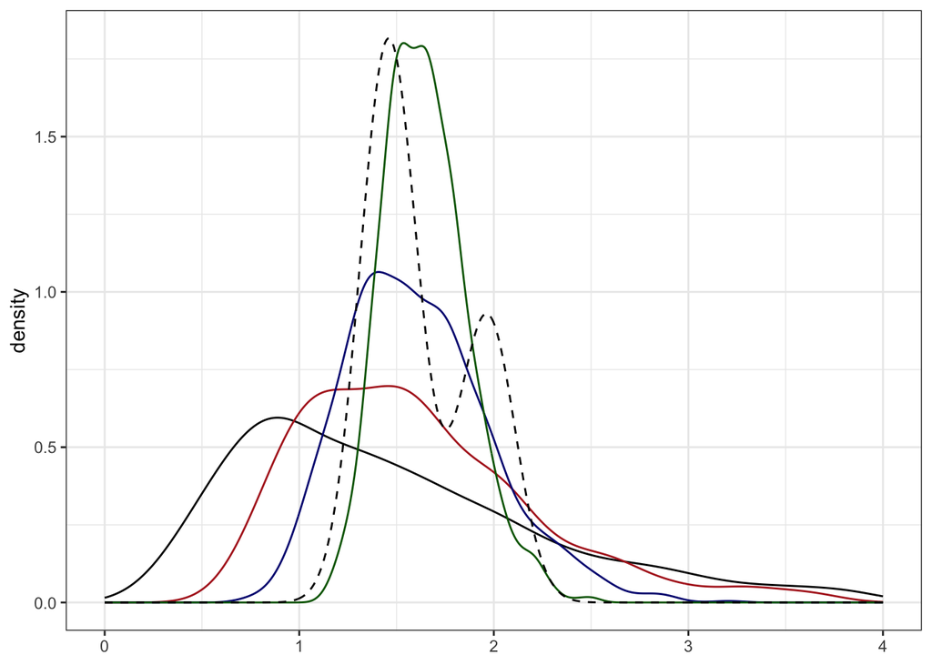

Moreover, from the normal distribution it is easy to find the region that contains $X\%$ of the area under the curve, or $X\%$ of the probability density. The parameter values that delineate this area define $X\%$ confidence interval (CI).

The interpretation of $X\%~ CI$ is that if we draw many samples and calculate as many means, then the true population mean falls inside $X\%$ of them. Formally, the CI makes a frequency statement about the error properties of the algorithm that calculates the CI, rather than about your sample mean. Nevertheless, if we have no background information to take into account and if the aforementioned assumptions (especially those of normality, and random and independent sampling) hold, then a confidence interval is numerically equivalent to Bayesian credible interval (also abbreviated as CI), whose interpretation is simply that $X\% ~CI$ means that the true expected value lies within this interval with X/100 probability. So you could view your confidence interval as a quick and dirty approximation to the credible interval, which you really want to have; but only if some strong assumptions hold.

This does not mean that your particular sample mean lies within the $X\%~ CI$ with $X\%$ probability.

The confidence interval is not the only, or even the most popular, tool of frequentist statistics. This distinction belongs to the p value.

**The logic of p value goes like this.**

1. As hypotheses do not have probabilities, but datasets do, we can speak of probability of data under some hypothesis – $P(d \vert h)$ or “probability of data given the hypothesis is true” – in the hope that this says something about the probability of that hypothesis, or $P(h \vert d)$.  
   For a two-group comparison (experimental values versus control values, say) the easiest way to do that is to define a null hypothesis, or $H_0$, whereby the means of the two groups are identical .

   that is, on average the experimental treatment has no effect at all or mean(treatment value) – mean(control value) = 0
2. Now, if there really is no effect, then by virtue of the sampling error we expect to see an effect anyway (this is called sampling effect or sampling error). And any true effect will be on top of the random sampling effect, which is equally likely to increase or decrease our estimate of the true effect. Therefore it is important to be able to distinguish between sampling effects and possible true effects. There are two possibilities. (*i*) If the true effect is not much larger than the sampling effect, they cannot be disentangled (at least not without collecting new samples). We must then say that the observed effect is consistent with the sampling effect and declare that we could not find evidence for any true non-random effect. (*ii*) If the observed effect is much larger than estimated sampling effect, then we can declare with confidence that the effect is non-random. Alas, non-randomness in no way guarantees that the effect was actually caused by the experimental treatment.
3. We model the sampling error of the $H_0$ as a normal distribution, whose mean equals zero (the zero effect) and whose standard deviation equals the sample standard deviation divided by the square root of N. The standard deviation of the means (as opposed to original data points) is called the standard error of the mean or SEM. If N is large enough (at least 30), then $mean +/- SEM = 68\%~ CI$, $mean +/- 1.96SEM = 95\% ~CI$ and $mean +/-3SEM = 99 \% ~CI$.

   The null hypothesis does not have to be normal, but historically they usually are.

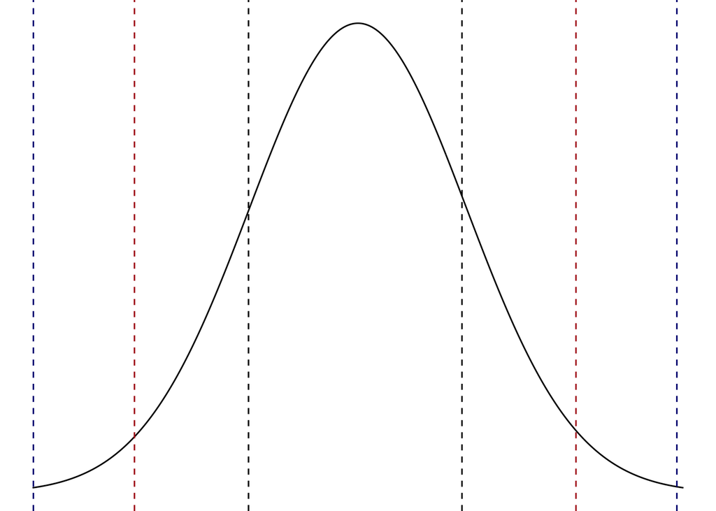

A null hypothesis with SEM, 1.96SEM, and 3SEM shown as black, red and blue dashed lines, respectively.

We use the sample data in estimating SEM of the $H_0$ because statistical software assumes that the scientific hardware (your brain) has no independent knowledge of the true population variation, and thus the sample values is used in lieu of population values. However, sample estimates of SEM can be highly misleading when N is small. Also, when the data is non-randomly drawn from the population, then even a very large sample is likely to be a poor representation of the population. As in many lab experiments N tends to be very small and it is often hard to even say, what a random sample means, $H_0$ testing tends not to work well in many branches of biology.

We now calculate the mean of our sample and superimpose it on the normal distribution of $H_0$. If our sample mean is situated where the $H_0$ distribution is still high, then it is consistent with the sample effect. On the other hand, if the height of the null distribution is very low, then the sample mean is inconsistent with the sample effect. Quantitatively, the fraction of the $H_0$ density that is cut of by our sample mean is the one-sided p value.

> p value is the long run relative frequency of obtaining data that is as far or further away from $H_0$ than your sample data, if the $H_0$ holds.

The p value was introduced by Roland Fisher in 1923 for use as an informal measure of strength of evidence. If p is small, 0.001, say, we might be tempted to claim that we have strong evidence that the $H_0$ is false.

This intuition can be very wrong.

A decade or so later Neyman and Pearson added to it something called significance level, often denoted by $\alpha$, and derived a quite different use for the p value in the long-term quality control of the experimental setup. In their scheme, which is mathematically impeccable, p value is not a direct comment on the experiment at hand, but rather on the experimental system that generated this experiment.

The goal of employing $\alpha$ is to provide an automatic procedure that makes discoveries, and does so with fixed error rates. By discovery we mean that “an effect is real”, or something like it. A discovery dichotomizes our contiuous measurements into statistically not significant non-discoveries and statistically significant discoveries, which can be either true discoveries or false discoveries (false-positives).

If $p < \alpha$, then we can call the p value statistically significant. By convention, $\alpha$ is set either as 0.01, 0.05 (the most often used value), or 0.1. By setting $\alpha$ we keep the long run relative frequency of type I errors at $\alpha$ level. This dichotomization, which comes at a cost of information loss, allows to define the frequency of **type I errors** as the relative frequency by which true $H_0$ are falsely classified as “statistically significant. Thereby we have a formal procedure that allows us to make discoveries without any more scientific input as data. If this actually worked, being a scientists would be a low-education job.

Thanks to $\alpha$, we can define the confidence interval through the p value: $X\%~ CI$ covers a range of parameter values, whose p values are not statistically significant at significance level $\alpha = 1 – X$. Thus, the CI and the p value carry redundant information.

The Neyman-Pearson procedure is fine, statistically speaking. But its use in science carries great dangers. When scientists employ it with $\alpha$ set to 0.05, they implicitly agree to publish on average every 20th true $H_0$ as a statistically significant false-positive finding. The level of harm that ensues depends on the true frequency of true effects. This is quantified as the False Discovery Rate (FDR), where FDR = false significant effects / all significant effects. If scientists test predominantly true effects (most experiments end up in showing a true effect of experimental treatment), then FDR is low and the use of statistical significance is not an obvious folly. On the other hand, if scientists are taking risks and testing hypotheses, most of which are false (most $H_0$s are true), then the Neyman-Pearson procedure leads to a terribly misleading picture of science as a whole. As philosophers seem to agree that testing risky hypotheses is what good scientists should be doing, therein obviously lies a problem.

## 3.2.2. Counting in the multiverse

Luckily for us, after 16th century with its borderline medieval thinking came the 17th and the scientific evolution. The thing that really unleashed scientific rationality was a question of gambling. Consider a game where 2 players equally pool their money to a pot that goes to the winner. The game is simple: they cast dice and after each round, whoever gets the largest sum, gets a point (draws don’t count). The game goes on until someone collects 9 points and wins the pot. But what happens when the game is suddenly interrupted after, say, player A has 7 points (and two to go) and player B has 8 points (and one to go)? Is there a just way of dividing the pot? This question bugged the best minds of Europe for centuries, when it was pretty universally thought that there isn’t a solution, until in 1654 Blaise Pascal and Pierre de Fermat solved it. While earlier attempts centered on getting an answer from the games actually played (the 8 and 7 points in our example), which led to contradiction, the insight of Fermat was that one could do a counterfactual analysis by pretending that the game goes on, albeit not in our world, but in an expanding array of parallel worlds.

The game continues in the multiverse

[figure not shown]

Here the starting point (A7B8) is in our universe. Then the 1st imaginary round splits it into two imaginary ones (A8B8 and A7B9), one of which leads to a win by player B. But on the next round player B does something that he would presumably never do in life: although there is no way for him to lose, he nevertheless keeps on playing and consequently in the second round the worlds split again, now into four. At this level every game ends in somebody winning and we can count the relative frequency of A-s wins (1) and B-s wins (3). Thus it makes sense to give ¼-th of the pot to A and ¾-th to B. This is the same as to say that P(A wins) = ¼ and P(B wins) = ¾. Probability theory is nothing but counting across the multiverse. Well, actually it is mostly about inventing algorithms that speed up this counting, as the multiverse, expanding exponentially, soon becomes non-conductive to hand-counting.

At a more conceptual level, we now have a frequency probability for a unique event. But in the multiverse everything has a frequency, and thus a probability. Since the summer of 1654, even scientific theories have probabilities. So we can bring to bear the mathematics of probability theory that is based on counting these frequencies.

## 3.3. From rules of combinatorics to probability distribution

## 3.3.1. The Addition Rule

Let $E_1$ and $E_2$ be mutually exclusive events. Let event $E$ describe the situation where either $E_1$ or $E_2$ will occur. The number of times event E will occur can be given by the expression:

$$n(E) = n(E_1) + n(E_2)$$

where

- $n(E)$ = Number of outcomes of event $E$
- $n(E_1)$ = Number of outcomes of event $E_1$
- $n(E_2)$ = Number of outcomes of event $E_2$

## 3.3.2. The Multiplication Rule

Suppose that $E_1$ can result in any one of $n(E_1)$ possible outcomes; and for each outcome of the event $E_1$, there are $n(E_2)$ possible outcomes of event $E_2$. Together there will be $n(E_1) × n(E_2)$ possible outcomes of the two events. That is, if event $E$ means that both $E_1$ and $E_2$ must occur, then

$$n(E) = n(E_1) \times n(E_2)$$

If you have a choice of $n_1$ elements for the 1st position, a choice of $n_2$ elements for the 2nd position, and so on up to $n_k$, then the number of possible combinations of sequences of k elements is $n_1 \times n_2 \times … \times n_k$.

## 3.3.3. Permutations

How many different combinations from 3 elements ABC can we get? The answer is 6: {ABC, ACB, BCA, BAC, CAB, CBC}. This generalizes to $n_1 = 3$, $n_2 = 2$, $n_3 = 1$ -> $n_1 \times n_2 \times n_3 = 6$, or by using n factorial: $n! = 3! = 3 \times 2 \times 1 = 6$.

n factorial is defined as the product of all the integers from 1 to n.

$$n! = (n)(n - 1)(n - 2) ... (3)(2)(1)$$

**n distinct objects can be arranged (permuted) in n! ways.**

## 3.3.4. Variations (the order matters and repetitions are not allowed)

n – nr of elements k – the length of the sequence

$$V_n^k = n(n - 1) … (n - k + 1) = n!/(n - k)!$$

8 athletes compete, how many different possibilities for the first three places? $n_1 = 8$, $n_2 = 7$, $n_3 = 6$

8 x 7 x 6 = 336

(8 - 3)! = 5!

8!/5! = 336

### 3.3.5. Combinations (the order is not important)

How many possible combinations of k elements is it logically possible to get of n distinct elements, or $\binom {n}{k}$?

$$\binom {n}{k} = \frac{n!}{k!(n - k)!}$$

There is a single way of obtaining 0 elements out of n possibilities

$$\binom {n}{0} = 1$$
and there is a single way of obtaining n elements out of n possibilities

$$\binom {n}{n} = 1$$

The number of different sets of 4 letters which can be chosen from the alphabet is $\binom {26}{4} = \frac{26!}{4!(26-4!)}$

## 3.3.6. From counting to binomial probability distribution

Q: What is the probability $P_n(k)$ that event A occurs exactly k times out of n tries?

1. we start by assuming that all k outcomes come up in an uninterrupted sequence. We look at the full series of n tries. Then by the multiplication rule:

$$P(A_1…A_k \lnot A_k + 1 …\lnot A_n) = P(A_1) …P(A_k)P(\lnot A_k + 1) … P(\lnot A_n) = p^k (1 - p)^{n-k}$$

We would get the same results no matter where the k outcomes are in the sequence. If the sample space only has two members: $\{0, 1\}$, a.k.a. if k is limited to only 0 or 1, and if n = 1, then this becomes Bernoulli probability mass distribution

$$f(k,p) = p^k(1 - p)^{n-k}$$

Example: if p = 0.1 and k=0, then $f(0, 0.1)= 0.1^0(0.9)^1=1 \times 0.9$; and $f(1, 0.1) = 0.1^1*0.9^0 = 0.1 \times 1$

This is, however, not the answer to our question, where both n and k can be any integer equal or larger than zero.

2. If k can be $>1$, then we also need to take into account that the nr of combinations of length n, where event A comes up k times, is

$$\binom{n}{k} = \frac{n!}{k!(n - k)!}$$

3. By multiplying 1. And 2. [Pr of a single series times the number of combinations with k events] we get
   $$P_n(k) = \binom{n}{k}p^k(1 - p)^{n-k}$$
   This is the binomial distribution.

Example: What is the Pr of getting 6 heads out of 10 coin tosses?
$$P_{10}(6)= \binom{10}{6} (1/2)^6 (1/2)^4 = (10!/(4!6!)) (1/2)^6 (1/2)^4 = 0.205$$
Table: Full binomial probability distribution for $P_{10}(5)$

| k | 0 & 10 | 1 & 9 | 2 & 8 | 3 & 7 | 4 & 6 | 5 | sum |
| --- | --- | --- | --- | --- | --- | --- | --- |
| Pn | 0.001 | 0.010 | 0.044 | 0.117 | 0.205 | 0.246 | 1.000 |

We can plot this probability distribution as a symmetric graph (it is symmetric as long as A and notA are equally probable).

## 3.4. Probability distribution

As probability measures epistemic uncertainty, the role of the probability distribution is to provide the full description of uncertainty over the sample space. The formal output of any statistical analysis is a probability distribution.

> A probability distribution lists for every member of sample space the probability of this member.

The sample space ($\Omega$) is the full set of mutually exclusive and exhaustive events/outcomes/hypotheses/parameter values that comprise all logically possible futures (the full multiverse).

$\Omega$ could be {$H_1$ – my wife is cheating on me; $H_2$ – my wife is not cheating on me}, or {$H_1$ – my wife is cheating on me with my best friend; $H_2$ – my wife is cheating on me, but not with my best friend; $H_3$ – my wife is not cheating on me}.

Importantly, we can slice the $\Omega$ cake in infinitely many ways, and the probability distribution that we end up with depends on the slicing. Whatever may be said of the downstream analysis, slicing the $\Omega$ is a scientific, rather than logical, exercise. A robot may well be able to calculate a probability distribution, but this will not turn it into a scientist!

## 3.4.1. Binomial disrtibution

For a coin throwing experiment the omega is $\{heads,~ tails\}$, for measurements of a continuous variable $\Omega$ is the infinite set of real numbers, and so on.

What sort of information does a probability distribution contain? Say, we have a fair coin which we toss 10 times and count the number of heads. We model this experiment as a Bernoulli process, leading to binomial probability distribution. The sample space X is then some number of heads between 0 and 10, a.k.a. X = $\{0, 1, …, 10 ~heads\}$.

Any sequence of experiments conforming to these requirements is a **Bernoulli process**.

- n independent experiments (tries), each with two possible outcomes ($\Omega = {A \land \lnot A}$).

  Sample space ($\Omega$) is a list of all possible outcomes.
- If $A_i$ is the outcome A in i-th experiment, the $P(A_i)$ is constant over the experiments
- $P(\lnot A) = 1 - P(A)$

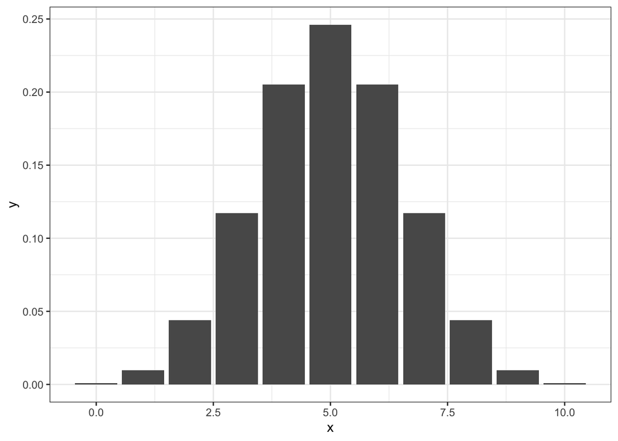

Binomial probability distribution models tossing of a coin. x is sample space, y denotes probability of each member of Omega.

```r
data <- tibble(x = 0:10,
               y = dbinom(x=x, size=10, prob=0.5))

ggplot(data=data, aes(x=x, y=y)) + geom_col() + theme_bw()
```

The most likely outcome of this experiment, X = 5, is at the highest point of the binomial distribution. And consequently, the higher the distribution over some value of X, the higher the probability that we will get as many heads from our experiment. We can look at this as a probability ratio – if the probability density over some value $X=x_j$ is two times higher than over some other value $X=x_k$, then the result $x_j$ is two times likelier to happen than the result $x_k$ (but note that both results may be a lot less likely than the most likely result). Thus, even before starting the experiment, we can ask the following kinds of questions, solely based on the probability distribution:

1. What is the most likely number of heads that we will get? Technically this is the expected value of X, or $EX$. The expected value of sample space X is the sum of each individual value $x_i$ times the probability $p_i$ of that value being the true value. It is also the value $X = x$, which is the center of mass of the probability distribution.
   $$EX = \sum x_ip_i$$
   or in R:

```r
(EX <- sum(data$x * data$y))
```

```
## [1] 5
```

Interpreting the EX is a thorny problem. Perhaps the most honest way to do this would be to imagine that every individual value, from which the EX was calculated, is in a bag in euro currency. Then, if you pay EX euros to extract a random value, this transaction will most probably allow you to stay even. For most purposes, this does not sound like a scientifically relevant interpretation. Importantly, the EX is not the most likely single value you might draw (this being the mode), nor is the value from which half the values are smaller/larger (this being the median). The EX is more popular than the mode or the median because historically it was often impossible to calculate CI-s and p values from the latter. In modern statistics this is no longer so. Thus you should choose your measure of central tendency/typical value based on scientific preferences.

For symmetrical probability distributions, incl. the normal distribution, the EX = mode = median.

2. What is the standard deviation of the probability distribution? We start by defining variance as $VX = \sum(x_i - EX)^2p$ where $x_i - E(X)$ is the deviation of i-th value from the expected value of X.
   $$SD(X) = \sqrt {VX}$$

```r
sqrt( sum( (data$x - EX)^2 * data$y) )
```

```
## [1] 1.581139
```

The range $EX +/- SD(X)$ usually covers about 2/3 of the values at the center of the distribution. For binomial distribution the variance is $V[X] = Np(1 - p)$, and if $Np$ is an integer, then mean = median = mode. Standard error for a proportion p is $\sqrt{\frac{p(1-p)}{N}}$.

3. What is the probability that the true value is greater than/smaller than/lies within an interval of X? If, for example, $2\%$ of the probability density lies beyond (is greater than) some value $x_i$ of X, then we say that the probability that $X > x_i$, or $P(X>x_i) = 0.02$.

To get the probability that we get 7 or more heads out of 10 coin tosses we sum the probabilities for every outcome with 7 or more heads:

```r
d1 <- data %>% filter(x >= 7)
sum(d1$y)
```

```
## [1] 0.171875
```

4. What interval of X covers some given fraction of the probability density? For example, if $95\%$ of the probability density lies between values $X = x_j$ and $X = x_k$, then we say that the true value of x lies within the interval $x_j$ and $x_k$ with $95\%$ probability. This is then the $95\%$ credible interval.

When I make 10 tosses, then how many heads will I get with 50% probability?

```r
a <- quantile(data$y, prob=0.5)
data %>% filter(y >= a)
```

```
## # A tibble: 7 × 2
##       x      y
##   <int>  <dbl>
## 1     2 0.0439
## 2     3 0.117
## 3     4 0.205
## 4     5 0.246
## 5     6 0.205
## 6     7 0.117
## 7     8 0.0439
```

In R dbinom() gives the density of binomial distribution. For example the probability of X = 3, or P(X=3) where $X \sim Binom(5, 0.2)$ is the same as

$$dbinom(3, 5, 0.2) = \binom{5}{3}(0.2)^3 (0.8)^2 = 0.0512$$

pbinom() is the cumulative density function (CDF), which takes first the value X where the function is evaluated, and then the 2 parameters of the binomial function.

$$pbinom(3, 5, 0.2 = \sum \binom{5}{k} (0.2)^k (0.8)^{5 - k} = 0.9933)$$

rbinom() generates binomial random variables. rbinom(10, 5, 0.5) generates 10 i.i.d. (independent and identically distributed) Bin(5, 0.5) random variables (10 numbers between 0 and 5, which are numbers of successes from 5 experiments, the whole thing repeated 10 times).

**Examples of binomial calculations in base::R**

- The probability of a particular outcome (probability of getting 5 heads out of 10 coin tosses if P(head)=0.5)

```r
dbinom(x=5, size=10, prob=0.5)
```

```
## [1] 0.2460938
```

Note that the probability of a particular outcome like k=5 successes is only computable in the discrete case. In the continuous case, the probability of obtaining a particular point value will always be zero.

- Using the dbinom() or pbinom(), we can get the cumulative probability of obtaining 1 or less, 2 or less successes.

```r
dbinom(0, size = 10, prob = 0.5) +
  dbinom(1, size = 10, prob = 0.5) +
  dbinom(2, size = 10, prob = 0.5)
```

```
## [1] 0.0546875
```

```r
#or equivalently

sum(dbinom(0:2, size = 10, prob = 0.5))
```

```
## [1] 0.0546875
```

```r
#or equivalently

pbinom(2, size = 10, prob = 0.5, lower.tail = TRUE)
```

```
## [1] 0.0546875
```

```r
# For the probability of obtaining 3 or more successes out of 10, lower.tail = FALSE
```

- We can also find out the value of the variable k (the quantile) such that the probability of obtaining k or less than k successes is some specific probability value p. This is the inverse of the cumulative distribution function (the quantile function). The inverse of the CDF (known as the quantile function in R because it returns the quantile, the value k) is available as qbinom(). What value k of the outcome is such that the probability of obtaining k or less successes is 0.37?

```r
qbinom(p=0.37, size = 10, prob = 0.5)
```

```
## [1] 4
```

- We generate simulated data (n data points) from a binomial distribution by specifying the number of trials and the probability of success

```r
rbinom(n=5, size=10, prob=0.5)
```

```
## [1] 7 5 7 1 2
```

Here we did 5 simulated coin tossing experiments, with 10 tosses each.

### 3.4.2 Poisson distribution

If you have a bernoulli sequence, whose number of events (successes) is much smaller than the number of experiments, then the binomial distribution can be converted into Poisson distribution, which only takes in the number events. Poisson distribution is a good data model if

- there are many chances for an event to occur, but taken one-by-one they are all unlikely
- these events are independent and exchangeable
- the frequency of events are constant (the elementary mechanisms generating the events do not change)
- two events cannot occur in the same time/place
- the probability of an event is proportional to an interval in time or space.

The number n of arrivals of a Poisson process in unit time is Poisson distributed. The single parameter is the rate $\lambda$ of the arrival of the Poisson process ($\lambda$ is an integer > 0). The Poisson paradigm is also called the law of rare events. The interpretation of “rare” is that the probability of event is small, not that $\lambda$ is small. For example, the low probability of getting an email from a specific person in a particular hour is offset by the large number of people who could send you an email in that hour.

$\lambda$ is also the expected value (the number of events), and its standard deviation is defined as $\sqrt \lambda$. Its formula is

$$f(x) = exp(- \lambda) \frac{\lambda^x}{x!}$$
If we have observed 5 events in a time interval (5 deaths in a week, say), then the probability that next week we will have 3 deaths is

```r
exp(-5)*(5^3/factorial(3))
```

```
## [1] 0.1403739
```

or

```r
dpois(3, 5)
```

```
## [1] 0.1403739
```

We can plot a Poisson probability distribution like this

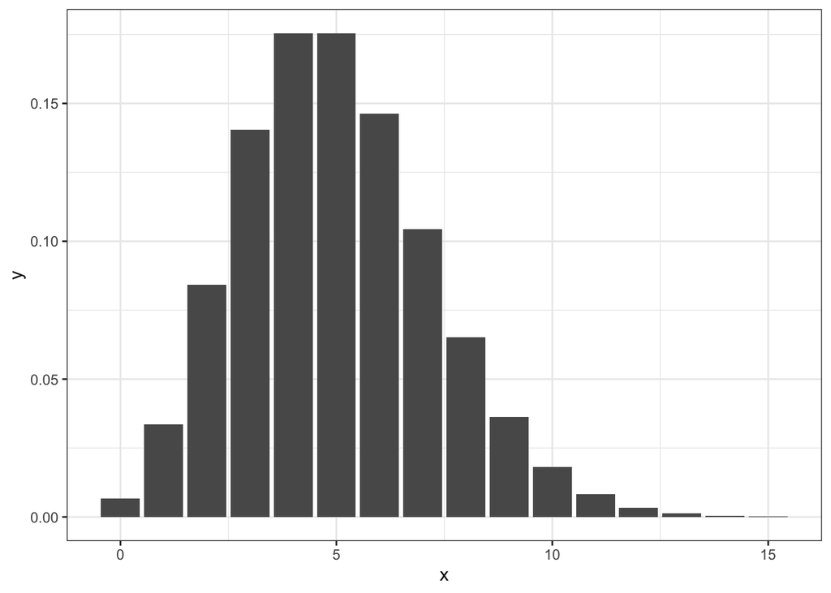

Poisson distribution for lambda = 5

```r
x <- 0:15
y <- dpois(x, 5)
ggplot(data=NULL, aes(x, y)) + geom_col() + theme_bw()
```

Often biological counts are overdispersed (larger Var than allowed by Poisson). **Negative binomial** (a.k.a. gamma-Poisson) is a mixture of Poisson distributions that have different $\lambda$s. In an overdispersion situation we may want to condition the model on X-vars that will convert the Y-var into a simple Poisson or binomial distribution. Then we do not need to use Negbinomial likelihood. Putting Poisson likelihood into a multi-level model can sometimes help. Negbinomial is a continuous mixture where each Poisson-distributed count comes from its own Poisson distribution. It is a continuous distribution that assumes that each Poisson process has its own $\lambda$ and that these $\lambda$s are gamma-distributed. Gamma distribution has two parameters, $\lambda$ and $\phi$.
$$y \sim NegBinomial(\lambda, \phi)$$
If $\phi$ gets close to zero, then NegBinomial gets close to normal distribution with the same $\mu$. if $\phi >0$, $Var(X)= \lambda + \lambda 2/\phi$. Larger $\phi$ gets the distribution closer to pure Poisson. In regression models with Poisson likelihoods we redefine $\lambda$ as a linear model with log-link.

For overdispersed binomial distributions we use **beta-binomial** likelihood, which assumes that each event has its own realization probability, and the probability distribution is the distribution of these probabilities, not of a single probability for all events. X-vars do not fix the probability of an individual event. Beta-binomial has 2 parameters: $p$ is the mean probability and $\theta$ is the shape parameter. $\theta=2$ gives a flat distribution between 0 and 1. Beta distribution is in the probability scale. Regression models with beta binomial likelihood look like this:

$$y \sim BetaBinom(n, p, \theta)$$
$$logit(p) = \beta X$$